# Project SUL- Bank Loan_solution

## Thera Bank Personal Loan Campaign

### 1] Import the datasets and libraries, check datatype, statistical summary,shape,null values or incorrect imputation. (5 marks)

precision-> Percntage of correct predictions Minimize FP Mimimize chances of campaign being sent to customers who are not likely to take loan. I dont want to frustate users with campaigns people are not interested in. I want to get highest coversion from what i identify.

recall-> percentage of correct pred/ictions out of actual users likely to take loan. Mimimize FN.Mimize chances of losing out customers who would take loan.Revenue first. Repercussions: budget

Precision is the ability to get the highest ratio of loan payers in the campaign, recall is the ability to not miss out on loan payers.

https://towardsdatascience.com/stop-saying-precision-and-recall-to-business-leaders-f17082ab5052

```python
import warnings
warnings.filterwarnings('ignore')
```

```python
## importing libaries

import pandas as pd
import numpy as np
import matplotlib.pyplot as plt
%matplotlib inline
import seaborn as sns
```

```python
# importing data

df = pd.read_csv("Bank_Personal_Loan_Modelling.csv")
df.head()      # used to see top 5 rows of the dataset
```

|  | ID | Age | Experience | Income | ZIP Code | Family | CCAvg | Education | Mortgage | Personal Loan | Securities Account | CD Account | Online | CreditCard |
| --- | --- | --- | --- | --- | --- | --- | --- | --- | --- | --- | --- | --- | --- | --- |
| 0 | 1 | 25 | 1 | 49 | 91107 | 4 | 1.6 | 1 | 0 | 0 | 1 | 0 | 0 | 0 |
| 1 | 2 | 45 | 19 | 34 | 90089 | 3 | 1.5 | 1 | 0 | 0 | 1 | 0 | 0 | 0 |
| 2 | 3 | 39 | 15 | 11 | 94720 | 1 | 1.0 | 1 | 0 | 0 | 0 | 0 | 0 | 0 |
| 3 | 4 | 35 | 9 | 100 | 94112 | 1 | 2.7 | 2 | 0 | 0 | 0 | 0 | 0 | 0 |
| 4 | 5 | 35 | 8 | 45 | 91330 | 4 | 1.0 | 2 | 0 | 0 | 0 | 0 | 0 | 1 |

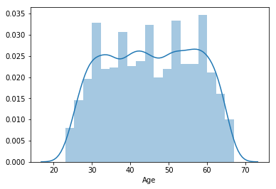

```python
sns.distplot(df['Age'])
```

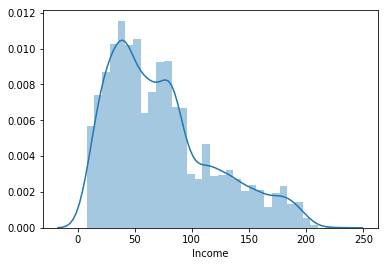

```python
sns.distplot(df['Income'])
```

```python
securitiesAcct=(df['Securities Account'].value_counts())

print('Value count of Securities Account, where 0:dont have one, 1:has account :')
print (securitiesAcct)
```

```
Value count of Securities Account, where 0:dont have one, 1:has account :
0    4478
1     522
Name: Securities Account, dtype: int64
```

```python
df.shape
```

```
(5000, 14)
```

```python
df.nunique()
```

```
ID                    5000
Age                     45
Experience              47
Income                 162
ZIP Code               467
Family                   4
CCAvg                  108
Education                3
Mortgage               347
Personal Loan            2
Securities Account       2
CD Account               2
Online                   2
CreditCard               2
dtype: int64
```

```python
df.dtypes        ## this would give datatype of each column
```

```
ID                      int64
Age                     int64
Experience              int64
Income                  int64
ZIP Code                int64
Family                  int64
CCAvg                 float64
Education               int64
Mortgage                int64
Personal Loan           int64
Securities Account      int64
CD Account              int64
Online                  int64
CreditCard              int64
dtype: object
```

```python
df.describe().T
```

|  | count | mean | std | min | 25% | 50% | 75% | max |
| --- | --- | --- | --- | --- | --- | --- | --- | --- |
| ID | 5000.0 | 2500.500000 | 1443.520003 | 1.0 | 1250.75 | 2500.5 | 3750.25 | 5000.0 |
| Age | 5000.0 | 45.338400 | 11.463166 | 23.0 | 35.00 | 45.0 | 55.00 | 67.0 |
| Experience | 5000.0 | 20.104600 | 11.467954 | -3.0 | 10.00 | 20.0 | 30.00 | 43.0 |
| Income | 5000.0 | 73.774200 | 46.033729 | 8.0 | 39.00 | 64.0 | 98.00 | 224.0 |
| ZIP Code | 5000.0 | 93152.503000 | 2121.852197 | 9307.0 | 91911.00 | 93437.0 | 94608.00 | 96651.0 |
| Family | 5000.0 | 2.396400 | 1.147663 | 1.0 | 1.00 | 2.0 | 3.00 | 4.0 |
| CCAvg | 5000.0 | 1.937938 | 1.747659 | 0.0 | 0.70 | 1.5 | 2.50 | 10.0 |
| Education | 5000.0 | 1.881000 | 0.839869 | 1.0 | 1.00 | 2.0 | 3.00 | 3.0 |
| Mortgage | 5000.0 | 56.498800 | 101.713802 | 0.0 | 0.00 | 0.0 | 101.00 | 635.0 |
| Personal Loan | 5000.0 | 0.096000 | 0.294621 | 0.0 | 0.00 | 0.0 | 0.00 | 1.0 |
| Securities Account | 5000.0 | 0.104400 | 0.305809 | 0.0 | 0.00 | 0.0 | 0.00 | 1.0 |
| CD Account | 5000.0 | 0.060400 | 0.238250 | 0.0 | 0.00 | 0.0 | 0.00 | 1.0 |
| Online | 5000.0 | 0.596800 | 0.490589 | 0.0 | 0.00 | 1.0 | 1.00 | 1.0 |
| CreditCard | 5000.0 | 0.294000 | 0.455637 | 0.0 | 0.00 | 0.0 | 1.00 | 1.0 |

```python
#There are negative numbmers in experience! maybe typing error.
# Convert to non-negative using .abs function

df['Experience'] = df['Experience'].abs()

df.describe().T
```

|  | count | mean | std | min | 25% | 50% | 75% | max |
| --- | --- | --- | --- | --- | --- | --- | --- | --- |
| ID | 5000.0 | 2500.500000 | 1443.520003 | 1.0 | 1250.75 | 2500.5 | 3750.25 | 5000.0 |
| Age | 5000.0 | 45.338400 | 11.463166 | 23.0 | 35.00 | 45.0 | 55.00 | 67.0 |
| Experience | 5000.0 | 20.134600 | 11.415189 | 0.0 | 10.00 | 20.0 | 30.00 | 43.0 |
| Income | 5000.0 | 73.774200 | 46.033729 | 8.0 | 39.00 | 64.0 | 98.00 | 224.0 |
| ZIP Code | 5000.0 | 93152.503000 | 2121.852197 | 9307.0 | 91911.00 | 93437.0 | 94608.00 | 96651.0 |
| Family | 5000.0 | 2.396400 | 1.147663 | 1.0 | 1.00 | 2.0 | 3.00 | 4.0 |
| CCAvg | 5000.0 | 1.937938 | 1.747659 | 0.0 | 0.70 | 1.5 | 2.50 | 10.0 |
| Education | 5000.0 | 1.881000 | 0.839869 | 1.0 | 1.00 | 2.0 | 3.00 | 3.0 |
| Mortgage | 5000.0 | 56.498800 | 101.713802 | 0.0 | 0.00 | 0.0 | 101.00 | 635.0 |
| Personal Loan | 5000.0 | 0.096000 | 0.294621 | 0.0 | 0.00 | 0.0 | 0.00 | 1.0 |
| Securities Account | 5000.0 | 0.104400 | 0.305809 | 0.0 | 0.00 | 0.0 | 0.00 | 1.0 |
| CD Account | 5000.0 | 0.060400 | 0.238250 | 0.0 | 0.00 | 0.0 | 0.00 | 1.0 |
| Online | 5000.0 | 0.596800 | 0.490589 | 0.0 | 0.00 | 1.0 | 1.00 | 1.0 |
| CreditCard | 5000.0 | 0.294000 | 0.455637 | 0.0 | 0.00 | 0.0 | 1.00 | 1.0 |

```python
df.isnull().sum()  #check for null Values
```

```
ID                    0
Age                   0
Experience            0
Income                0
ZIP Code              0
Family                0
CCAvg                 0
Education             0
Mortgage              0
Personal Loan         0
Securities Account    0
CD Account            0
Online                0
CreditCard            0
dtype: int64
```

## EDA

### 2] EDA: Study the data distribution in each attribute and target variable, share your findings (20 marks)

Number of unique in each column?

Number of people with zero mortgage?

Number of people with zero credit card spending per month?

Value counts of all categorical columns.

Univariate and Bivariate

Get data model ready

```python
# Column descriptions

## Data Description:

##	ID	Customer ID

##	Age	Customer's age in completed years

##	Experience	#years of professional experience

##	Income	Annual income of the customer ($000)

##	ZIPCode	Home Address ZIP code.

##	Family	Family size of the customer

##	CCAvg	Avg. spending on credit cards per month ($000)

##	Education	Education Level. 1: Undergrad; 2: Graduate; 3: Advanced/Professional

##	Mortgage	Value of house mortgage if any. ($000)

##	Personal Loan	Did this customer accept the personal loan offered in the last campaign? 0 - False and 1 - True

##	Securities Account	Does the customer have a securities account with the bank? 0 - False and 1 - True

##	CD Account	Does the customer have a certificate of deposit (CD) account with the bank? 0 - False and 1 - True

##	Online	Does the customer use internet banking facilities? 0 - False and 1 - True

##	CreditCard	Does the customer use a credit card issued by UniversalBank? 0 - False and 1 - True
```

```python
df.nunique()
# gives number of unique values in each column
```

```
ID                    5000
Age                     45
Experience              44
Income                 162
ZIP Code               467
Family                   4
CCAvg                  108
Education                3
Mortgage               347
Personal Loan            2
Securities Account       2
CD Account               2
Online                   2
CreditCard               2
dtype: int64
```

```python
df.drop(['ID','ZIP Code'],axis=1,inplace=True)

# dropping 'ID' column as it all the unique value and this column wont provide any insight to build a model
# Zip Code represents region and region wise distribution of customers is not helping here
# as alot region are there in just 5000 customers, therefore dropping 'ZIP Code'
```

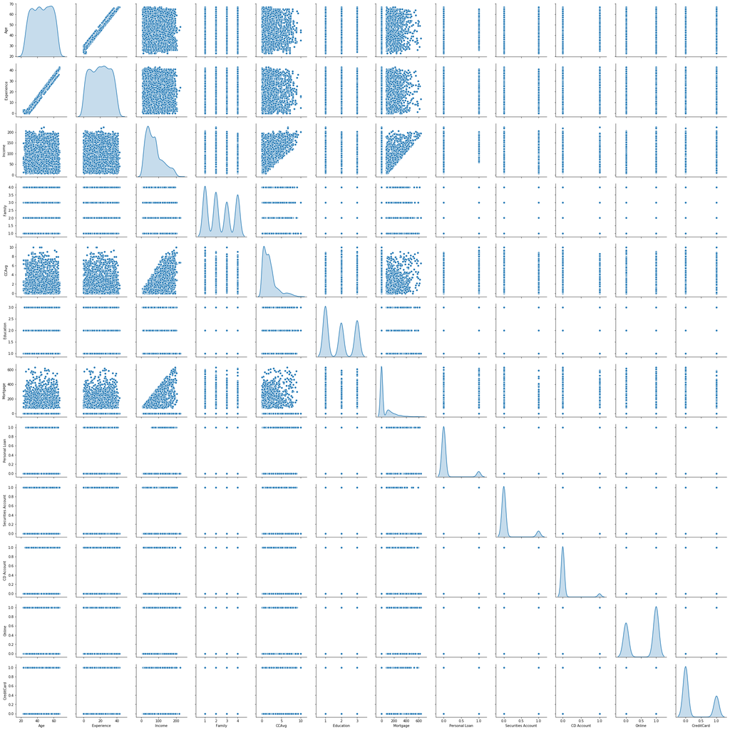

```python
sns.pairplot(df,diag_kind='kde')
plt.show()
```

```python
# Age and experience have strong positive relation
# Age and Experience have uniform distribution
# Income is positively skewed
```

### Target Variable is Personal Loan

```python
vc = df[['Personal Loan', 'Securities Account', 'CD Account',
       'Online', 'CreditCard']].sum().reset_index().rename(columns={'index':'Col_Name',0:"Value_Count_1"})
vc['Value_Count_0'] = df.shape[0] - vc['Value_Count_1']
vc

# Value counts of all the category column with two unique values (0,1)
```

|  | Col_Name | Value_Count_1 | Value_Count_0 |
| --- | --- | --- | --- |
| 0 | Personal Loan | 480 | 4520 |
| 1 | Securities Account | 522 | 4478 |
| 2 | CD Account | 302 | 4698 |
| 3 | Online | 2984 | 2016 |
| 4 | CreditCard | 1470 | 3530 |

```
0    90.4
1     9.6
Name: Personal Loan, dtype: float64
```

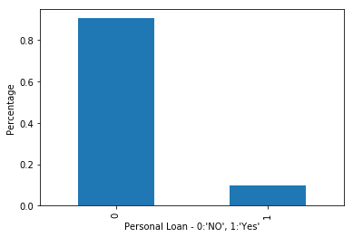

```python
print(df['Personal Loan'].value_counts(normalize=True)*100)
print()
df['Personal Loan'].value_counts(normalize=True).plot(kind='bar')
plt.xlabel("Personal Loan - 0:'NO', 1:'Yes'")
plt.ylabel("Percentage")
plt.show()
```

```python
df[df['Mortgage']==0].shape[0]/len(df)

#count of people having home mortgage as zero, Most of the people donot have mortgage
```

```
0.6924
```

```python
pd.crosstab(df['Personal Loan'], df['Online'],normalize='columns')
```

| Online Personal Loan | 0 | 1 |
| --- | --- | --- |
| 0 | 0.90625 | 0.90248 |
| 1 | 0.09375 | 0.09752 |

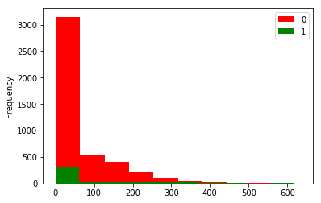

```python
df[df['Personal Loan']==0]['Mortgage'].plot.hist(color='r',label=0)
df[df['Personal Loan']==1]['Mortgage'].plot.hist(color='g',label=1)
plt.legend()
plt.show()

# Most people with zero motgage are not taking personal loans
```

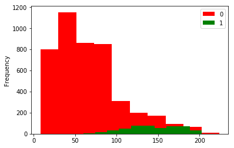

```python
df[df['Personal Loan']==0]['Income'].plot.hist(color='r',label=0)
df[df['Personal Loan']==1]['Income'].plot.hist(color='g',label=1)
plt.legend()
plt.show()

# Number of People with high income taking personal loan are high as compared to low income
```

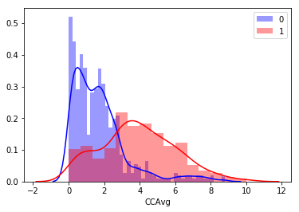

```python
sns.distplot(df[df['Personal Loan']==0]['CCAvg'],color='b',label='0')
sns.distplot(df[df['Personal Loan']==1]['CCAvg'],color='r',label='1')
plt.legend()
plt.show()

# People with high avg credit card spending per month are taking personal loans
```

```python
df[df['CCAvg']==0].shape[0]/len(df)

#count of people having zero monthly spending on credit card
```

```
0.0212
```

```python
df['Family'] = df['Family'].astype('category')
df['Education'] = df['Education'].astype('category')
```

```python
df.Education.value_counts()
```

```
1    2096
3    1501
2    1403
Name: Education, dtype: int64
```

### 3] Split the data into training and test set in the ratio of 70:30 respectively (5 marks)

```python
# Separate the independent attributes i.e. every column except personal loan
# Store the target column (Personal Loan) into Y array

x = df.loc[:, df.columns != 'Personal Loan']  # independent variables

y = df.loc[:, df.columns == 'Personal Loan']  # Target variable
```

```python
x = pd.get_dummies(x,drop_first=True)
```

```python
y.head()
```

|  | Personal Loan |
| --- | --- |
| 0 | 0 |
| 1 | 0 |
| 2 | 0 |
| 3 | 0 |
| 4 | 0 |

```python
x.head()
```

|  | Age | Experience | Income | CCAvg | Mortgage | Securities Account | CD Account | Online | CreditCard | Family_2 | Family_3 | Family_4 | Education_2 | Education_3 |
| --- | --- | --- | --- | --- | --- | --- | --- | --- | --- | --- | --- | --- | --- | --- |
| 0 | 25 | 1 | 49 | 1.6 | 0 | 1 | 0 | 0 | 0 | 0 | 0 | 1 | 0 | 0 |
| 1 | 45 | 19 | 34 | 1.5 | 0 | 1 | 0 | 0 | 0 | 0 | 1 | 0 | 0 | 0 |
| 2 | 39 | 15 | 11 | 1.0 | 0 | 0 | 0 | 0 | 0 | 0 | 0 | 0 | 0 | 0 |
| 3 | 35 | 9 | 100 | 2.7 | 0 | 0 | 0 | 0 | 0 | 0 | 0 | 0 | 1 | 0 |
| 4 | 35 | 8 | 45 | 1.0 | 0 | 0 | 0 | 0 | 1 | 0 | 0 | 1 | 1 | 0 |

### 4] Use Logistic Regression model to predict the likelihood of a customer buying personal loans. Print all the metrics related for evaluating the model performance (15 marks)

```python
# Create the training and test data set in the ratio of 70:30 respectively. Can be of any ratio...

from sklearn.model_selection import train_test_split

xtrain,xtest,ytrain,ytest = train_test_split(x,y,test_size=0.3,random_state=7)

# Random state seeding for reapeatability of the code
# if random state is not mentioned it would generate different train test sample in every run
# test_size is to select the size of test data

# two variables taken for split therefore output will generate 4 variables: test train for x and test train for y
```

```python
xtrain.head()
```

|  | Age | Experience | Income | CCAvg | Mortgage | Securities Account | CD Account | Online | CreditCard | Family_2 | Family_3 | Family_4 | Education_2 | Education_3 |
| --- | --- | --- | --- | --- | --- | --- | --- | --- | --- | --- | --- | --- | --- | --- |
| 717 | 59 | 34 | 94 | 0.5 | 0 | 0 | 0 | 0 | 1 | 0 | 1 | 0 | 0 | 0 |
| 2496 | 63 | 37 | 32 | 0.7 | 141 | 0 | 0 | 0 | 0 | 0 | 1 | 0 | 1 | 0 |
| 2469 | 43 | 18 | 89 | 0.1 | 307 | 0 | 0 | 0 | 1 | 0 | 0 | 0 | 1 | 0 |
| 1375 | 50 | 26 | 179 | 2.9 | 0 | 0 | 0 | 0 | 1 | 0 | 0 | 0 | 0 | 1 |
| 2742 | 39 | 14 | 89 | 0.4 | 0 | 0 | 0 | 1 | 0 | 1 | 0 | 0 | 0 | 0 |

```python
xtest.head()
```

|  | Age | Experience | Income | CCAvg | Mortgage | Securities Account | CD Account | Online | CreditCard | Family_2 | Family_3 | Family_4 | Education_2 | Education_3 |
| --- | --- | --- | --- | --- | --- | --- | --- | --- | --- | --- | --- | --- | --- | --- |
| 3406 | 42 | 12 | 34 | 2.0 | 0 | 0 | 0 | 0 | 1 | 0 | 1 | 0 | 0 | 1 |
| 757 | 52 | 28 | 81 | 1.8 | 0 | 1 | 0 | 0 | 0 | 0 | 1 | 0 | 1 | 0 |
| 3624 | 58 | 28 | 70 | 1.4 | 0 | 0 | 0 | 0 | 0 | 0 | 0 | 0 | 0 | 1 |
| 4544 | 28 | 4 | 80 | 2.5 | 0 | 0 | 0 | 1 | 0 | 0 | 1 | 0 | 0 | 0 |
| 3235 | 60 | 35 | 39 | 1.6 | 0 | 0 | 0 | 1 | 0 | 1 | 0 | 0 | 0 | 1 |

#### Base Model

```python
from sklearn.linear_model import LogisticRegression   # importing logistic regression from scikit learn

model = LogisticRegression(random_state=7)  #assigning a variable for the algorithm

model.fit(xtrain, ytrain) #training of model
```

```
LogisticRegression(C=1.0, class_weight=None, dual=False, fit_intercept=True,
                   intercept_scaling=1, l1_ratio=None, max_iter=100,
                   multi_class='auto', n_jobs=None, penalty='l2',
                   random_state=7, solver='lbfgs', tol=0.0001, verbose=0,
                   warm_start=False)
```

```python
y_predict = model.predict(xtest)     #model is predicting y values based on test dataset given to the model

print("Trainig accuracy",model.score(xtrain,ytrain))  # this will give training accuracy as training data has been used
print()
print("Testing accuracy",model.score(xtest, ytest))   # this will give testing accuracy as testing data has been used
```

```
Trainig accuracy 0.9568571428571429

Testing accuracy 0.9613333333333334
```

```python
print(recall_score(ytest,y_predict))

print(precision_score(ytest,y_predict))

print(f1_score(ytest,y_predict))

print(roc_auc_score(ytest,y_predict))
```

```
0.6594202898550725
0.8921568627450981
0.7583333333333333
0.825671965779225
```

```python
from sklearn.linear_model import LogisticRegression   # importing logistic regression from scikit learn

model = LogisticRegression(random_state=7,class_weight='balanced')  #assigning a variable for the algorithm

model.fit(xtrain, ytrain) #training of model
```

```
LogisticRegression(C=1.0, class_weight='balanced', dual=False,
                   fit_intercept=True, intercept_scaling=1, l1_ratio=None,
                   max_iter=100, multi_class='auto', n_jobs=None, penalty='l2',
                   random_state=7, solver='lbfgs', tol=0.0001, verbose=0,
                   warm_start=False)
```

```python
print(recall_score(ytest,y_predict))

print(precision_score(ytest,y_predict))

print(f1_score(ytest,y_predict))

print(roc_auc_score(ytest,y_predict))
```

[output not shown]

```python
y_predict = model.predict(xtest)     #model is predicting y values based on test dataset given to the model

print("Trainig accuracy",model.score(xtrain,ytrain))  # this will give training accuracy as training data has been used
print()
print("Testing accuracy",model.score(xtest, ytest))   # this will give testing accuracy as testing data has been used
```

```
Trainig accuracy 0.8965714285714286

Testing accuracy 0.9113333333333333
```

```python
#### Here the model performs better in testing than training. Therefore, it is a good model
```

```python
from sklearn.metrics import confusion_matrix, recall_score, precision_score, f1_score, roc_auc_score

## importing necessary metrics to evaluate model performance
```

```python
## function to get confusion matrix in a proper format
def draw_cm( actual, predicted ):
    cm = confusion_matrix( actual, predicted,normalize=True)
    sns.heatmap(cm, annot=True,  fmt='.0f', xticklabels = [0,1] , yticklabels = [0,1] )
    plt.ylabel('Observed')
    plt.xlabel('Predicted')
    plt.show()
```

[figure not shown]

```python
draw_cm(ytest,y_predict)
```

```python
recall_score(ytest,y_predict)
```

```
0.6594202898550725
```

```python
recall_score(ytest,y_predict)
```

```
0.6594202898550725
```

```python
precision_score(ytest,y_predict)
```

```
0.8921568627450981
```

```python
precision_score(ytest,y_predict)
```

```
0.8921568627450981
```

```python
f1_score(ytest,y_predict)
```

```
0.7583333333333333
```

```python
roc_auc_score(ytest,y_predict)
```

```
0.825671965779225
```

```python
roc_auc_score(ytest,y_predict)
```

[output not shown]